# MA5755_Project: Loan Default Prediction

Group-9

2022-05-17

### Introduction

#### Problem

In this project, we want to know the chance that some customers will default their loan payment and use that as a parameter to decide whether to approve or disapprove the loan. Also, to identify and specifically target the customers segments, those are eligible for loan amount

#### Objective

The goal of this project is to build a model that will classify if a certain customer will default its loan payment or not.

#### Dataset Description

Dream Housing Finance company deals in all home loans. They have presence across all urban, semi urban and rural areas. Customer first apply for home loan after that company validates the customer eligibility for loan. Company wants to automate the loan eligibility process (real time) based on customer detail provided while filling online application form. These details are Gender, Marital Status, Education, Number of Dependents, Income, Loan Amount, Credit History and others. We are using there partial data set available on Kaggle Platform.

### Importing the data set

```r
data <- read.csv('loan_data_set.csv')
```

### Checking for the structure of the data

```r
str(data)
```

```
## 'data.frame':    614 obs. of  13 variables:
##  $ Loan_ID          : chr  "LP001002" "LP001003" "LP001005" "LP001006" ...
##  $ Gender           : chr  "Male" "Male" "Male" "Male" ...
##  $ Married          : chr  "No" "Yes" "Yes" "Yes" ...
##  $ Dependents       : chr  "0" "1" "0" "0" ...
##  $ Education        : chr  "Graduate" "Graduate" "Graduate" "Not Graduate" ...
##  $ Self_Employed    : chr  "No" "No" "Yes" "No" ...
##  $ ApplicantIncome  : int  5849 4583 3000 2583 6000 5417 2333 3036 4006 12841 ...
##  $ CoapplicantIncome: num  0 1508 0 2358 0 ...
##  $ LoanAmount       : int  NA 128 66 120 141 267 95 158 168 349 ...
##  $ Loan_Amount_Term : int  360 360 360 360 360 360 360 360 360 360 ...
##  $ Credit_History   : int  1 1 1 1 1 1 1 0 1 1 ...
##  $ Property_Area    : chr  "Urban" "Rural" "Urban" "Urban" ...
##  $ Loan_Status      : chr  "Y" "N" "Y" "Y" ...
```

The data set consist of 614 observations with 13 variables out which there are 8 character variables, 4 integer variables and 1 numeric variable.

#### Convert all character columns to factor

```r
data <- as.data.frame(unclass(data), stringsAsFactors = TRUE)
str(data)
```

```
## 'data.frame':    614 obs. of  13 variables:
##  $ Loan_ID          : Factor w/ 614 levels "LP001002","LP001003",..: 1 2 3 4 5 6 7 8 9 10 ...
##  $ Gender           : Factor w/ 3 levels "","Female","Male": 3 3 3 3 3 3 3 3 3 3 ...
##  $ Married          : Factor w/ 3 levels "","No","Yes": 2 3 3 3 2 3 3 3 3 3 ...
##  $ Dependents       : Factor w/ 5 levels "","0","1","2",..: 2 3 2 2 2 4 2 5 4 3 ...
##  $ Education        : Factor w/ 2 levels "Graduate","Not Graduate": 1 1 1 2 1 1 2 1 1 1 ...
##  $ Self_Employed    : Factor w/ 3 levels "","No","Yes": 2 2 3 2 2 3 2 2 2 2 ...
##  $ ApplicantIncome  : int  5849 4583 3000 2583 6000 5417 2333 3036 4006 12841 ...
##  $ CoapplicantIncome: num  0 1508 0 2358 0 ...
##  $ LoanAmount       : int  NA 128 66 120 141 267 95 158 168 349 ...
##  $ Loan_Amount_Term : int  360 360 360 360 360 360 360 360 360 360 ...
##  $ Credit_History   : int  1 1 1 1 1 1 1 0 1 1 ...
##  $ Property_Area    : Factor w/ 3 levels "Rural","Semiurban",..: 3 1 3 3 3 3 3 2 3 2 ...
##  $ Loan_Status      : Factor w/ 2 levels "N","Y": 2 1 2 2 2 2 2 1 2 1 ...
```

All the 8 character variables are now converted to categorical variables.

### Extract top 10 observations

```r
head(data, n = 10)
```

```
##     Loan_ID Gender Married Dependents    Education Self_Employed
## 1  LP001002   Male      No          0     Graduate            No
## 2  LP001003   Male     Yes          1     Graduate            No
## 3  LP001005   Male     Yes          0     Graduate           Yes
## 4  LP001006   Male     Yes          0 Not Graduate            No
## 5  LP001008   Male      No          0     Graduate            No
## 6  LP001011   Male     Yes          2     Graduate           Yes
## 7  LP001013   Male     Yes          0 Not Graduate            No
## 8  LP001014   Male     Yes         3+     Graduate            No
## 9  LP001018   Male     Yes          2     Graduate            No
## 10 LP001020   Male     Yes          1     Graduate            No
##    ApplicantIncome CoapplicantIncome LoanAmount Loan_Amount_Term Credit_History
## 1             5849                 0         NA              360              1
## 2             4583              1508        128              360              1
## 3             3000                 0         66              360              1
```

[output cut: 18 more lines]

### Data Pre-processing

#### Checking for the structure and other possible incompleteness

```r
summary(data)
```

```
##      Loan_ID       Gender    Married   Dependents        Education
##  LP001002:  1         : 13      :  3     : 15     Graduate    :480
##  LP001003:  1   Female:112   No :213   0 :345     Not Graduate:134
##  LP001005:  1   Male  :489   Yes:398   1 :102
##  LP001006:  1                          2 :101
##  LP001008:  1                          3+: 51
##  LP001011:  1
##  (Other) :608
##  Self_Employed ApplicantIncome CoapplicantIncome   LoanAmount
##     : 32       Min.   :  150   Min.   :    0     Min.   :  9.0
##  No :500       1st Qu.: 2878   1st Qu.:    0     1st Qu.:100.0
##  Yes: 82       Median : 3812   Median : 1188     Median :128.0
##                Mean   : 5403   Mean   : 1621     Mean   :146.4
##                3rd Qu.: 5795   3rd Qu.: 2297     3rd Qu.:168.0
##                Max.   :81000   Max.   :41667     Max.   :700.0
##                                                  NA's   :22
##  Loan_Amount_Term Credit_History     Property_Area Loan_Status
##  Min.   : 12      Min.   :0.0000   Rural    :179   N:192
##  1st Qu.:360      1st Qu.:1.0000   Semiurban:233   Y:422
##  Median :360      Median :1.0000   Urban    :202
##  Mean   :342      Mean   :0.8422
##  3rd Qu.:360      3rd Qu.:1.0000
##  Max.   :480      Max.   :1.0000
##  NA's   :14       NA's   :50
```

The summary reveals that there are some blank spaces. For instance: Gender has 13 blank spaces, Married has 3, Dependents has 15, Self_Employed has 32, LoanAmount has 22, Loan_Amount_Term has 14 & Credit_History has 50. Which sums to 149.

More so, the summary statistics gives us a view of the skewness of the numeric variables;i.e how close or far away the mean is from the median(middle) mainly for numeric data.

#### Replacing blank spaces with NAs

```r
data[data == ""] <- NA
```

We have been able to replace the blank spaces with NA’s which will now be captured by R as a missing number.

#### Checking for missing data

```r
sum(is.na(data))
```

```
## [1] 149
```

This shows that there are 149 missing values in the data set

#### Summary of the data

```r
summary(data)
```

```
##      Loan_ID       Gender    Married    Dependents        Education
##  LP001002:  1         :  0       :  0       :  0   Graduate    :480
##  LP001003:  1   Female:112   No  :213   0   :345   Not Graduate:134
##  LP001005:  1   Male  :489   Yes :398   1   :102
##  LP001006:  1   NA's  : 13   NA's:  3   2   :101
##  LP001008:  1                           3+  : 51
##  LP001011:  1                           NA's: 15
##  (Other) :608
##  Self_Employed ApplicantIncome CoapplicantIncome   LoanAmount
##      :  0      Min.   :  150   Min.   :    0     Min.   :  9.0
##  No  :500      1st Qu.: 2878   1st Qu.:    0     1st Qu.:100.0
##  Yes : 82      Median : 3812   Median : 1188     Median :128.0
##  NA's: 32      Mean   : 5403   Mean   : 1621     Mean   :146.4
##                3rd Qu.: 5795   3rd Qu.: 2297     3rd Qu.:168.0
##                Max.   :81000   Max.   :41667     Max.   :700.0
##                                                  NA's   :22
##  Loan_Amount_Term Credit_History     Property_Area Loan_Status
##  Min.   : 12      Min.   :0.0000   Rural    :179   N:192
##  1st Qu.:360      1st Qu.:1.0000   Semiurban:233   Y:422
##  Median :360      Median :1.0000   Urban    :202
##  Mean   :342      Mean   :0.8422
##  3rd Qu.:360      3rd Qu.:1.0000
##  Max.   :480      Max.   :1.0000
##  NA's   :14       NA's   :50
```

The summary statistic has now clearly shown the missing numbers and variables that has the missing values. For instance, Dependents now has 15 NA’s as compared to 15 blank spaces it has earlier.

#### Handling missing number using KNN Imputation method

```r
library(VIM)
```

```r
#Picking the columns with missing number
data1 <- kNN(data,variable = c("Gender","Married","Dependents","Self_Employed","LoanAmount","Loan_Amount_Term",
                               "Credit_History"), k = 7)
summary(data1)
```

```
##      Loan_ID       Gender    Married   Dependents        Education
##  LP001002:  1         :  0      :  0     :  0     Graduate    :480
##  LP001003:  1   Female:113   No :213   0 :354     Not Graduate:134
##  LP001005:  1   Male  :501   Yes:401   1 :103
##  LP001006:  1                          2 :106
##  LP001008:  1                          3+: 51
##  LP001011:  1
##  (Other) :608
##  Self_Employed ApplicantIncome CoapplicantIncome   LoanAmount
##     :  0       Min.   :  150   Min.   :    0     Min.   :  9.0
##  No :532       1st Qu.: 2878   1st Qu.:    0     1st Qu.:100.0
##  Yes: 82       Median : 3812   Median : 1188     Median :127.0
##                Mean   : 5403   Mean   : 1621     Mean   :145.4
##                3rd Qu.: 5795   3rd Qu.: 2297     3rd Qu.:165.0
##                Max.   :81000   Max.   :41667     Max.   :700.0
##
##  Loan_Amount_Term Credit_History     Property_Area Loan_Status Gender_imp
##  Min.   : 12.0    Min.   :0.0000   Rural    :179   N:192       Mode :logical
##  1st Qu.:360.0    1st Qu.:1.0000   Semiurban:233   Y:422       FALSE:601
##  Median :360.0    Median :1.0000   Urban    :202               TRUE :13
##  Mean   :342.4    Mean   :0.8453
##  3rd Qu.:360.0    3rd Qu.:1.0000
##  Max.   :480.0    Max.   :1.0000
##
##  Married_imp     Dependents_imp  Self_Employed_imp LoanAmount_imp
##  Mode :logical   Mode :logical   Mode :logical     Mode :logical
##  FALSE:611       FALSE:599       FALSE:582         FALSE:592
##  TRUE :3         TRUE :15        TRUE :32          TRUE :22
##
##
##
##
##  Loan_Amount_Term_imp Credit_History_imp
##  Mode :logical        Mode :logical
##  FALSE:600            FALSE:564
##  TRUE :14             TRUE :50
##
##
##
##
```

#### Subsetting the data

```r
data1 <- subset(data1, select = Loan_ID:Loan_Status)
sum(is.na(data1))
```

```
## [1] 0
```

The data set now has 0 missing values.

#### Summary of the data

```r
library(psych)
describe(data1)
```

```
##                   vars   n    mean      sd median trimmed     mad min   max
## Loan_ID*             1 614  307.50  177.39  307.5  307.50  227.58   1   614
## Gender*              2 614    2.82    0.39    3.0    2.89    0.00   2     3
## Married*             3 614    2.65    0.48    3.0    2.69    0.00   2     3
## Dependents*          4 614    2.76    1.01    2.0    2.60    0.00   2     5
## Education*           5 614    1.22    0.41    1.0    1.15    0.00   1     2
## Self_Employed*       6 614    2.13    0.34    2.0    2.04    0.00   2     3
## ApplicantIncome      7 614 5403.46 6109.04 3812.5 4292.06 1822.86 150 81000
## CoapplicantIncome    8 614 1621.25 2926.25 1188.5 1154.85 1762.07   0 41667
## LoanAmount           9 614  145.44   84.31  127.0  132.36   45.96   9   700
## Loan_Amount_Term    10 614  342.41   64.43  360.0  358.54    0.00  12   480
## Credit_History      11 614    0.85    0.36    1.0    0.93    0.00   0     1
## Property_Area*      12 614    2.04    0.79    2.0    2.05    1.48   1     3
## Loan_Status*        13 614    1.69    0.46    2.0    1.73    0.00   1     2
##                   range  skew kurtosis     se
## Loan_ID*            613  0.00    -1.21   7.16
## Gender*               1 -1.63     0.65   0.02
## Married*              1 -0.64    -1.59   0.02
## Dependents*           3  0.97    -0.45   0.04
## Education*            1  1.36    -0.15   0.02
## Self_Employed*        1  2.15     2.62   0.01
## ApplicantIncome   80850  6.51    59.83 246.54
## CoapplicantIncome 41667  7.45    83.97 118.09
## LoanAmount          691  2.72    10.70   3.40
## Loan_Amount_Term    468 -2.39     6.83   2.60
## Credit_History        1 -1.90     1.63   0.01
## Property_Area*        2 -0.07    -1.39   0.03
## Loan_Status*          1 -0.81    -1.35   0.02
```

Describes gives us a broad range of summary statistics.

### Exploratory Data Analysis

### Correlation Matrix

#### Checking for correlation and multicollinearity between the variables

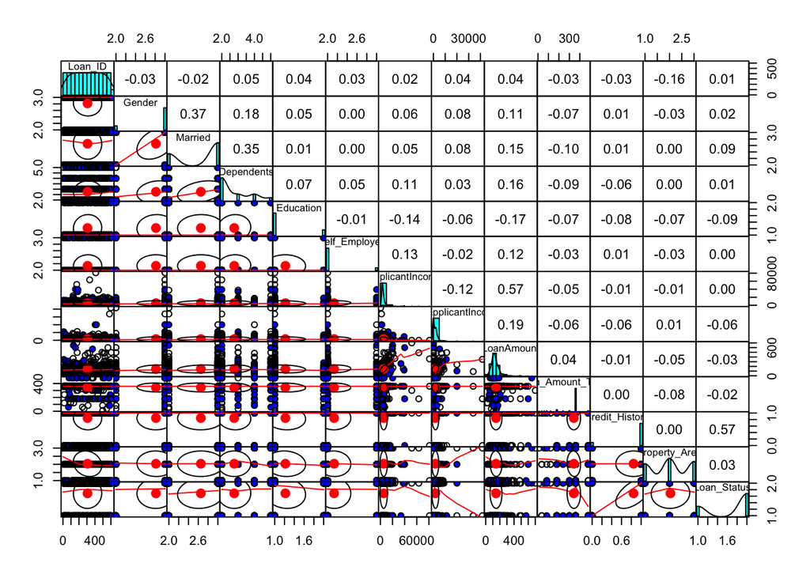

```r
library(psych)
pairs.panels (data1, gap = 0, bg = c("red","green","blue"[data1$Loan_Status]), pch = 21)
```

### Checking for outlier

#### using Box Plot

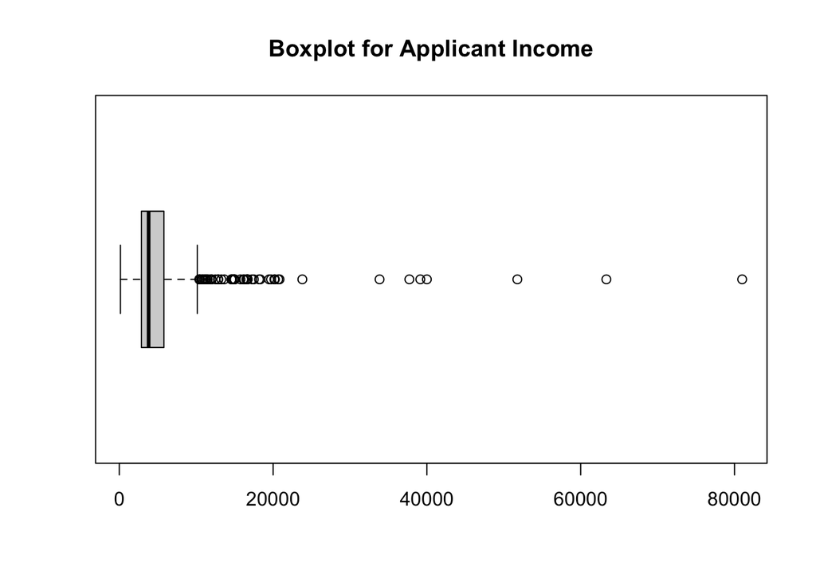

```r
boxplot(data1$ApplicantIncome, horizontal = TRUE, main = "Boxplot for Applicant Income")
```

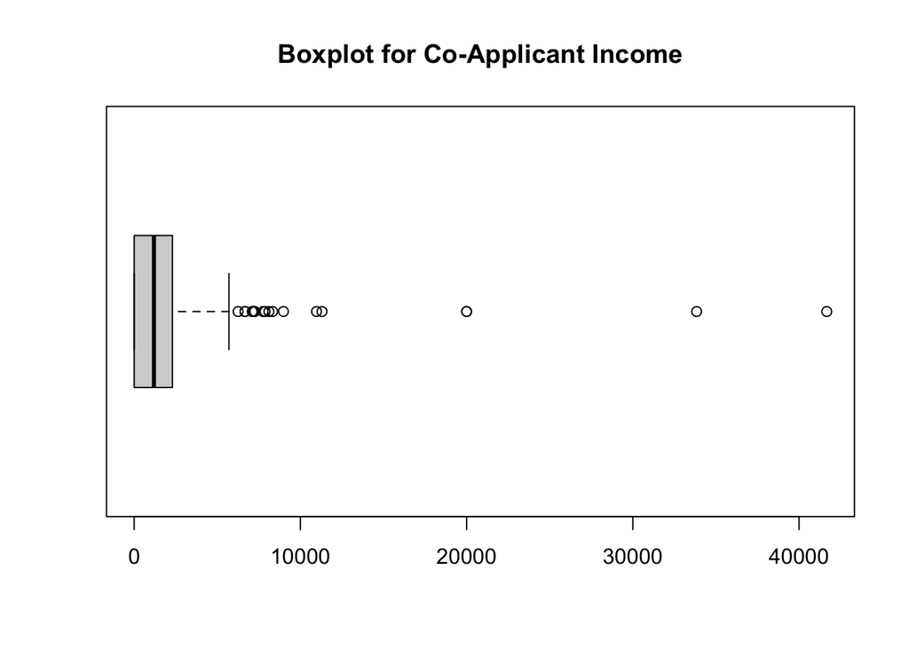

```r
boxplot(data1$CoapplicantIncome, horizontal = TRUE, main = "Boxplot for Co-Applicant Income")
```

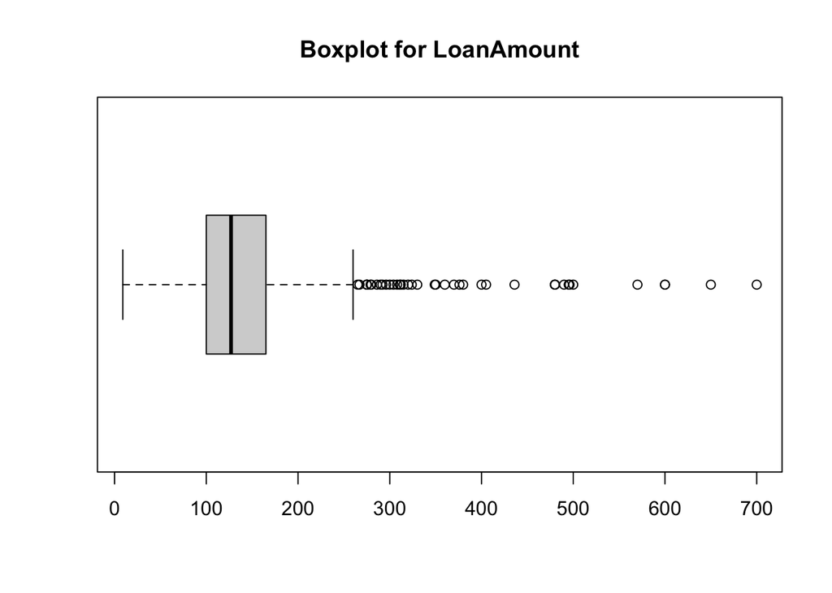

```r
boxplot(data1$LoanAmount, horizontal = TRUE, main = "Boxplot for LoanAmount")
```

### Outlier Treatment for ApplicantIncome,CoapplicantIncome and LoanAmount

#### ApplicantIncome

```r
bench <- 5795 + 1.5*IQR(data1$ApplicantIncome) #Q3 + 1.5*IQR(data)
bench
```

```
## [1] 10171.25
```

```r
#Winsorizing method of treating outlier
data1$ApplicantIncome[data1$ApplicantIncome > bench]
```

```
##  [1] 12841 12500 11500 10750 13650 11417 14583 10408 23803 10513 20166 14999
## [13] 11757 14866 39999 51763 33846 39147 12000 11000 16250 14683 11146 14583
## [25] 20667 20233 15000 63337 19730 15759 81000 14880 12876 10416 37719 16692
## [37] 16525 16667 10833 18333 17263 20833 13262 17500 11250 18165 19484 16666
## [49] 16120 12000
```

```r
data1$ApplicantIncome[data1$ApplicantIncome > bench] <- bench
summary(data1$ApplicantIncome)
```

```
##    Min. 1st Qu.  Median    Mean 3rd Qu.    Max.
##     150    2878    3812    4617    5795   10171
```

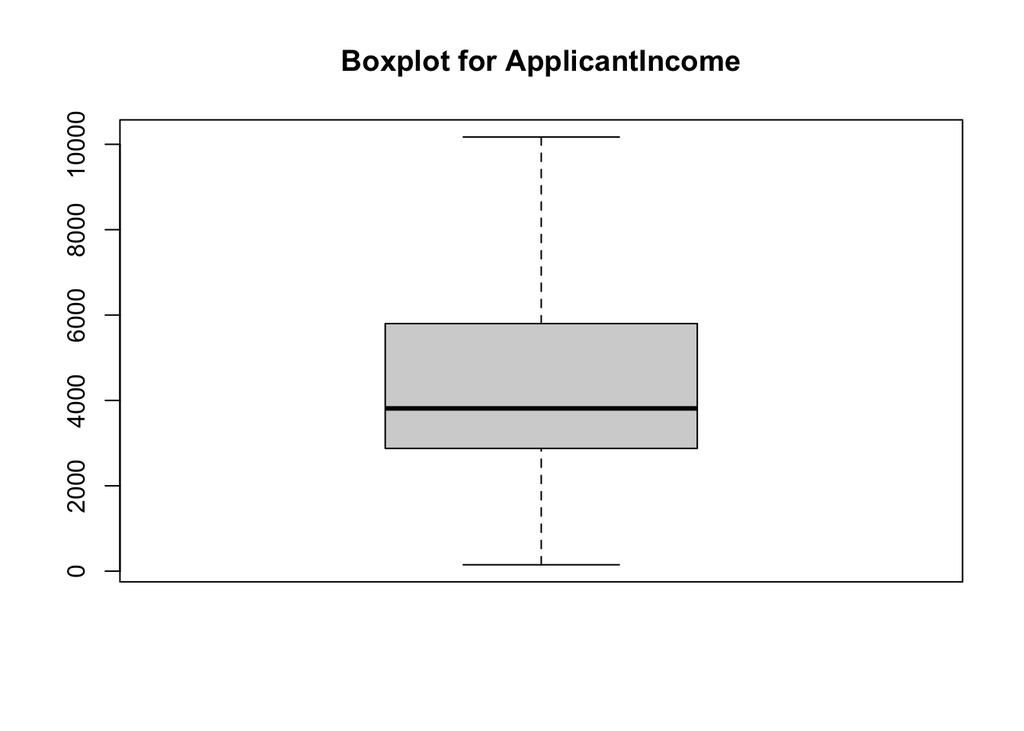

```r
boxplot(data1$ApplicantIncome, main = "Boxplot for ApplicantIncome")
```

```r
length(data1$ApplicantIncome)
```

```
## [1] 614
```

#### CoapplicantIncome

```r
bench <- 2297 + 1.5*IQR(data1$CoapplicantIncome) #Q3 + 1.5*IQR(data)
bench
```

```
## [1] 5742.875
```

```r
#Winsorizing method of treating outlier
data1$CoapplicantIncome[data1$CoapplicantIncome > bench]
```

```
##  [1] 10968  8106  7210  8980  7750 11300  7250  7101  6250  7873 20000 20000
## [13]  8333  6667  6666  7166 33837 41667
```

```r
data1$CoapplicantIncome[data1$CoapplicantIncome > bench] <- bench
summary(data1$CoapplicantIncome)
```

```
##    Min. 1st Qu.  Median    Mean 3rd Qu.    Max.
##       0       0    1188    1420    2297    5743
```

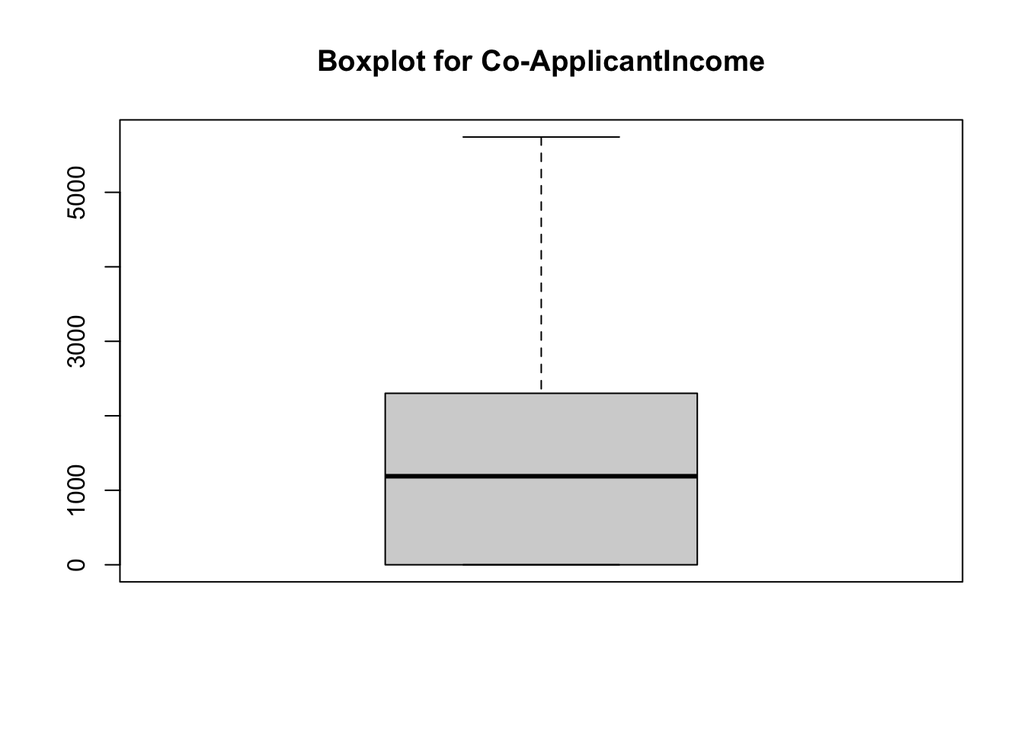

```r
boxplot(data1$CoapplicantIncome, main = "Boxplot for Co-ApplicantIncome")
```

```r
length(data1$CoapplicantIncome)
```

```
## [1] 614
```

#### LoanAmount

```r
bench <- 165 + 1.5*IQR(data1$LoanAmount) #Q3 + 1.5*IQR(data)
bench
```

```
## [1] 262.5
```

```r
#Winsorizing method of treating outlier
data1$LoanAmount[data1$LoanAmount > bench]
```

```
##  [1] 267 349 315 320 286 312 265 370 650 290 600 275 700 495 280 279 304 330 436
## [20] 480 300 376 490 308 570 380 296 275 360 405 500 480 311 480 400 324 600 275
## [39] 292 350 496
```

```r
data1$LoanAmount[data1$LoanAmount > bench] <- bench
summary(data1$LoanAmount)
```

```
##    Min. 1st Qu.  Median    Mean 3rd Qu.    Max.
##     9.0   100.0   127.0   137.1   165.0   262.5
```

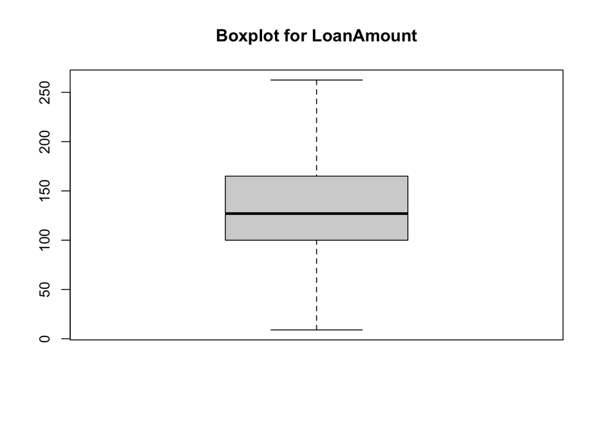

```r
boxplot(data1$LoanAmount, main = "Boxplot for LoanAmount")
```

```r
length(data1$LoanAmount)
```

```
## [1] 614
```

```r
prop.table(table(data1$Loan_Status))
```

```
##
##         N         Y
## 0.3127036 0.6872964
```

```r
table(data1$Loan_Status)
```

```
##
##   N   Y
## 192 422
```

Class imbalance is a situation, mostly in classification model building; where the total number of positive class of a data set is extremely lower than the total number of the negative class.

In the data set, we have 68.7% of the response variable as YES and 31.3% as NO.Hence, we can conclude that there is no class imbalance in this data set.

### Train & Test set

```r
set.seed(222)
split = sample(2,nrow(data1),prob = c(0.75, 0.25),replace = TRUE)
train_set = data1[split == 1,]
test_set = data1[split == 2,]
```

It is the usual practice in Machine Learning field to divide the data set into train and test set. The model will be built on the train set and the performance of the model will be tested on the test.

### Logistic Regression

Logistic regression uses sigmoid function to classify variables into classes and its basically applicable to classification problems. Other applicable models for classification problems are Decision Tree, Random Forest, Naive Bayes, Neural Network and so on.

For the purpose of this project we will be using Decision Tree and Random Forest along with Logistic Regression.

```r
# Fitting Logistic Regression to the Training set
logistics_classifier = glm(formula = Loan_Status ~ ., family = binomial, data = train_set[,-c(1)])

summary(logistics_classifier)
```

```
##
## Call:
## glm(formula = Loan_Status ~ ., family = binomial, data = train_set[,
##     -c(1)])
##
## Deviance Residuals:
##     Min       1Q   Median       3Q      Max
## -2.5053  -0.2664   0.4892   0.6704   2.9847
##
## Coefficients:
##                          Estimate Std. Error z value Pr(>|z|)
## (Intercept)            -3.264e+00  1.104e+00  -2.957  0.00311 **
## GenderMale             -4.700e-01  3.624e-01  -1.297  0.19467
## MarriedYes              8.505e-01  3.025e-01   2.812  0.00492 **
## Dependents1            -5.073e-01  3.502e-01  -1.449  0.14746
## Dependents2             3.955e-01  4.208e-01   0.940  0.34720
## Dependents3+            2.084e-01  5.196e-01   0.401  0.68838
## EducationNot Graduate  -3.708e-01  3.120e-01  -1.189  0.23461
## Self_EmployedYes        2.908e-01  4.014e-01   0.724  0.46881
## ApplicantIncome         3.910e-05  7.913e-05   0.494  0.62124
## CoapplicantIncome       1.384e-04  1.019e-04   1.357  0.17467
## LoanAmount             -5.965e-03  3.422e-03  -1.743  0.08129 .
## Loan_Amount_Term       -3.480e-04  2.173e-03  -0.160  0.87274
## Credit_History          4.763e+00  6.181e-01   7.706  1.3e-14 ***
## Property_AreaSemiurban  8.167e-01  3.192e-01   2.559  0.01050 *
## Property_AreaUrban      3.627e-01  3.146e-01   1.153  0.24893
## ---
## Signif. codes:  0 '***' 0.001 '**' 0.01 '*' 0.05 '.' 0.1 ' ' 1
##
## (Dispersion parameter for binomial family taken to be 1)
##
##     Null deviance: 591.70  on 471  degrees of freedom
## Residual deviance: 397.02  on 457  degrees of freedom
## AIC: 427.02
##
## Number of Fisher Scoring iterations: 5
```

Based on the output of the Logistic regression,only 3 variables are significant while other are insignificant.

Credit_History is an important factor in deciding whether a client will default or not and this was clearly in tune with the outcome of the model. Whether the customer is married or not is also a significant factor, as far as this data set is concerned.

#### Prediction using Logistics Regression

```r
# Predicting the Test set results
prob_pred = predict(logistics_classifier, type = 'response', newdata = test_set)
y_pred = ifelse(prob_pred > 0.5, 1, 0)
```

#### Estimating the performance of the model

```r
# Confusion Matrix
cm = table(ActualValue=test_set$Loan_Status, PredictedValue=prob_pred > 0.5)
cm
```

```
##            PredictedValue
## ActualValue FALSE TRUE
##           N    17   24
##           Y     4   97
```

```r
#Estimating the percentage of performance
sum(diag(cm))/sum(cm)
```

```
## [1] 0.8028169
```

Logistics Regression was able to give us an accuracy of 80.28%, which means that we can expect our model to classify correct about 8 observations in every 10.

### Decision Tree

```r
library(party)
Tree_Classifer = ctree(Loan_Status ~ ., data = train_set[,-c(1)])
Tree_Classifer
```

```
##
##   Conditional inference tree with 3 terminal nodes
##
## Response:  Loan_Status
## Inputs:  Gender, Married, Dependents, Education, Self_Employed, ApplicantIncome, CoapplicantIncome, LoanAmount, Loan_Amount_Term, Credit_History, Property_Area
## Number of observations:  472
##
## 1) Credit_History <= 0; criterion = 1, statistic = 164.631
##   2)*  weights = 74
## 1) Credit_History > 0
##   3) Married == {Yes}; criterion = 0.975, statistic = 9.784
##     4)*  weights = 266
##   3) Married == {No}
##     5)*  weights = 132
```

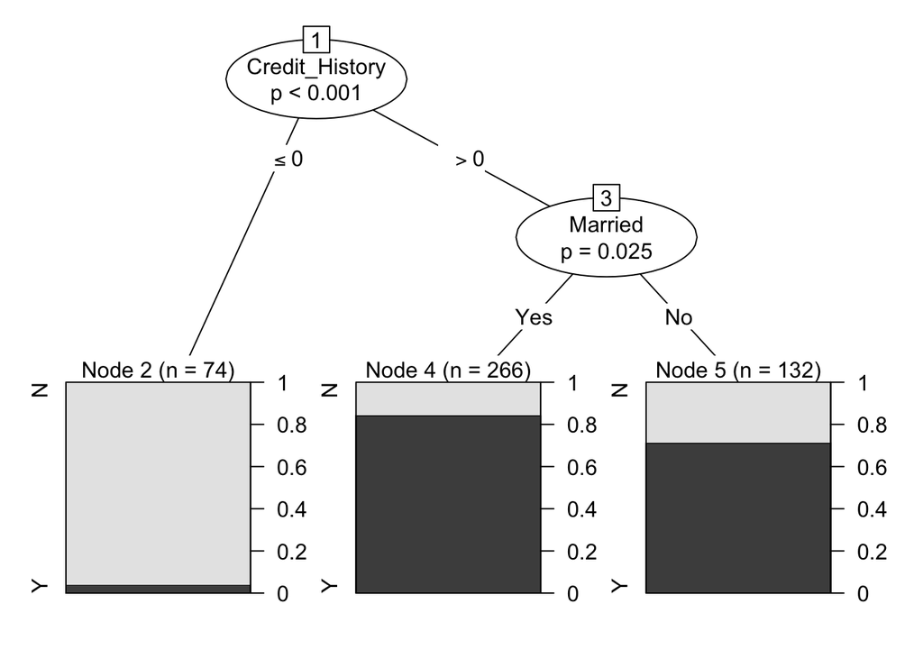

```r
plot(Tree_Classifer)
```

The decision tree model also corroborated the position of the logistic regression by making credit_history as the most important variable for consideration when deciding if a customer is going to default or not.

#### Prediction using Decision Tree

```r
# Predicting the Test set results
pred = predict(Tree_Classifer, newdata = test_set)
```

#### Estimating the performance of the model

```r
# Confusion Matrix
cm = table(ActualValue=test_set$Loan_Status, PredictedValue=pred)
cm
```

```
##            PredictedValue
## ActualValue  N  Y
##           N 17 24
##           Y  4 97
```

```r
#Estimating the percentage of performance
sum(diag(cm))/sum(cm)
```

```
## [1] 0.8028169
```

The level of accuracy achieved by the Decision Tree model is similar to that of logistics regression at 80.28%

### Random Forest

Random Forest is ensemble method in that it averages the performance of 500 Decision Trees to arrive at its output where Decision Tree employs only just one Tree.The 500 tree were chosen at random. Its the reason the model is regarded as Random Forest.

```r
library(randomForest)
set.seed(153)
rf_classifier <- randomForest(Loan_Status ~ ., data = train_set[,-c(1)])

str(rf_classifier)
```

[output not shown]

[output cut: 19 more lines]

[output not shown]

```r
attributes(rf_classifier)
```

```
## $names
##  [1] "call"            "type"            "predicted"       "err.rate"
##  [5] "confusion"       "votes"           "oob.times"       "classes"
##  [9] "importance"      "importanceSD"    "localImportance" "proximity"
## [13] "ntree"           "mtry"            "forest"          "y"
## [17] "test"            "inbag"           "terms"
##
## $class
## [1] "randomForest.formula" "randomForest"
```

#### Prediction using Random Forest

```r
# Predicting the Test set results
rf_pred = predict(rf_classifier,newdata = test_set)
```

#### Estimating the performance of the model

```r
# Confusion Matrix
cm = table(ActualValue=test_set$Loan_Status, PredictedValue=rf_pred)
cm
```

```
##            PredictedValue
## ActualValue  N  Y
##           N 18 23
##           Y  6 95
```

```r
#Estimating the percentage of performance
sum(diag(cm))/sum(cm)
```

```
## [1] 0.7957746
```

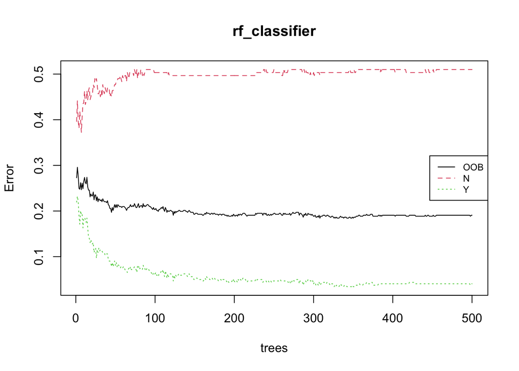

```r
plot(rf_classifier)
legend("right", cex = 0.75, legend = {colnames(rf_classifier$err.rate)}, lty=c(1,2,3), col=c(1,2,3), horiz=F)
```

#### Determining the most important variable in the forest

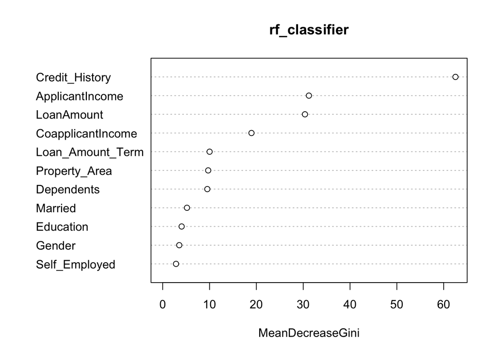

```r
varImpPlot(rf_classifier)
```

```r
importance(rf_classifier)
```

```
##                   MeanDecreaseGini
## Gender                    3.530676
## Married                   5.179226
## Dependents                9.523031
## Education                 4.039186
## Self_Employed             2.844527
## ApplicantIncome          31.216106
## CoapplicantIncome        18.954701
## LoanAmount               30.374947
## Loan_Amount_Term         10.008232
## Credit_History           62.516014
## Property_Area             9.711490
```

The Random Forest model also ranked Credit_History as the most important variable just the other 2 previous models. While Random Forest agree that ApplicantIncome is another important variable; Logistics regression chose Married.